# Spatial R - NMNH Fall 2016

by Nicole F. Angeli

December 8, 2016

# GIS: a tool to display and integrate complex data

GIS: Geographical Information Systems (GIS) a computer-based system to aid in the collection, maintenance, storage, analysis, output, and distribution of spatial data

## LOAD LIBRARIES

```r
#library(shapefiles)
#library(lattice)
#library(rgeos)
#library(sp)
library(raster)
library(plyr)
library(rgdal)
library(phytools)
```

## TYPES OF GIS DATA:

> GIS data is comprised of **locations** (geographic/spatial data) & **attributes** (properties; non-spatial data) What are types of locations? What are types of attributes?

> GIS data may be displayed as a vector or raster. Vector data represents entities as exactly as possible while raster data represents continuous surfaces.

#### VECTOR DATA

> - point - a single point location (x,y coordinate pair)
> - line - a sequence of ordered coordinate pairs
> - polygon - an area, marked by a sequence of interconnected lines

#### RASTER DATA

> - grid - a collection of points or cells organized in a regular lattice

## Importing data for sp and raster is handled in the package ‘rgdal’

```r
shapefiles<-readOGR("typeFile") #no extension
rasters<-readGDAL("typeFile.extension")
```

## Importing data in package ‘maptools’

```r
library(maptools)
points.mp <- readShapePoints("mypoints")
lines.mp <- readShapeLines("mylines")
shapes.mp <- readShapePoly("myshapes")
```

## SPATIAL DATA CLASSES USED BY PACKAGE sp

### DATA TYPE : DATA CLASS : ATTRIBUTES

> - points : SpatialPoints : none
> - points : SpatialPointsDataFrame : data.frame
> - lines : SpatialLines : none
> - lines : SpatialLinesDataFrame : data.frame
> - polygons : SpatialPolygons : none
> - polygons : SpatialPolygonsDataFrame : data.frame
> - pixels : SpatialPixels : none
> - pixels : SpatialPixelsDataFrame : data.frame
> - grid : SpatialGrid : none
> - grid : SpatialGridDataFrame : data.frame

> Shapefiles have multiple kinds of data: how many do you see associated with the provided data? * .prj – plain text file of projection * .sbn and *.sbx – spatial index of features* .atx – index of attributes * .shp.xml – metadata

### Mandatory files

> - .shp — shape format; the feature geometry itself
> - .shx — shape index format; a positional index of the feature geometry to allow seeking forwards and backwards quickly
> - .dbf — attribute format; columnar attributes for each shape, in dBase IV format

### Other files

> - .prj — projection format; the coordinate system and projection information, a plain text file describing the projection using well-known text format
> - .sbn and .sbx — a spatial index of the features
> - .fbn and .fbx — a spatial index of the features that are read-only
> - .ain and .aih — an attribute index of the active fields in a table
> - .ixs — a geocoding index for read-write datasets
> - .mxs — a geocoding index for read-write datasets (ODB format)
> - .atx — an attribute index for the .dbf file in the form of shapefile.columnname.atx (ArcGIS 8 and later)
> - .shp.xml — geospatial metadata in XML format, such as ISO 19115 or other XML schema
> - .cpg — used to specify the code page (only for .dbf) for identifying the character encoding to be used
> - .qix — an alternative quadtree spatial index used by MapServer and GDAL/OGR software ####thanks, Wikipedia

# Meuse example: Points, Lines, Polygons, Grid

# POINTS (sites sampled)

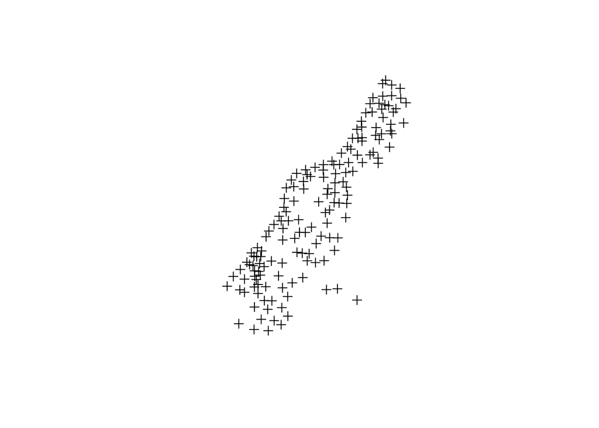

```r
data(meuse)
coordinates(meuse) <- c("x", "y")
plot(meuse)
```

#### LINE (path walked)

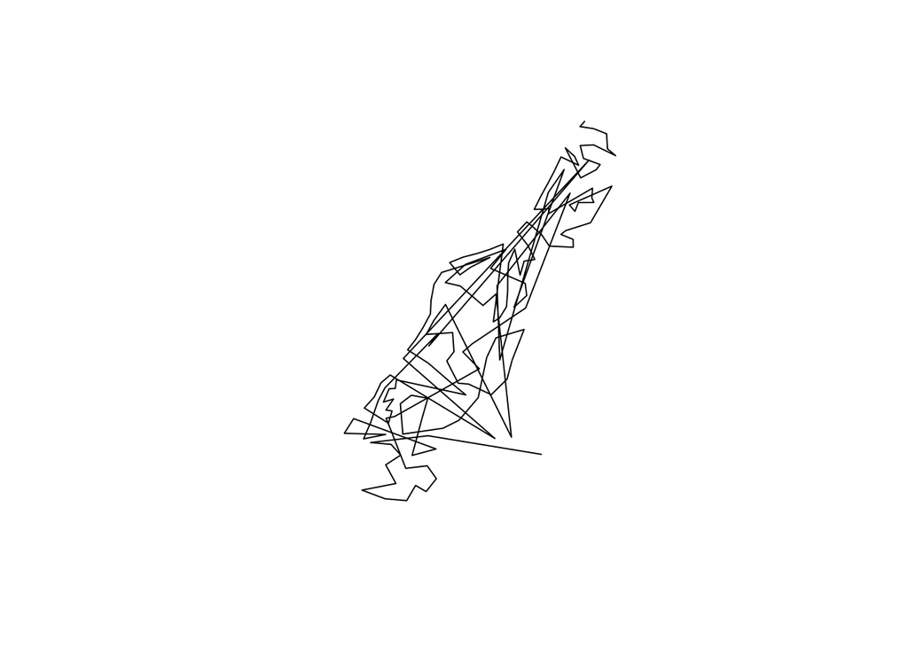

```r
cc <- coordinates(meuse)
m.sl <- SpatialLines(list(Lines(list(Line(cc)),"1"))) #connects points
plot(m.sl)
```

#### POLYGON (river)

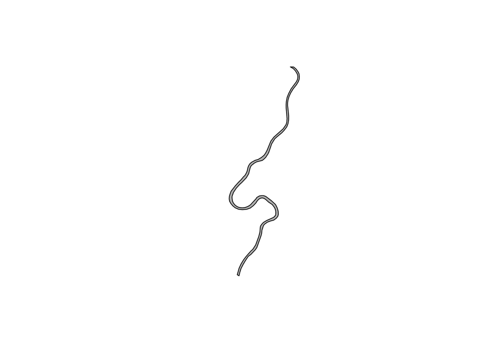

```r
data(meuse.riv)
meuse.lst <- list(Polygons(list(Polygon(meuse.riv)), "meuse.riv"))
meuse.sr <- SpatialPolygons(meuse.lst)
plot(meuse.sr, col = "grey")
```

### GRID (study area)

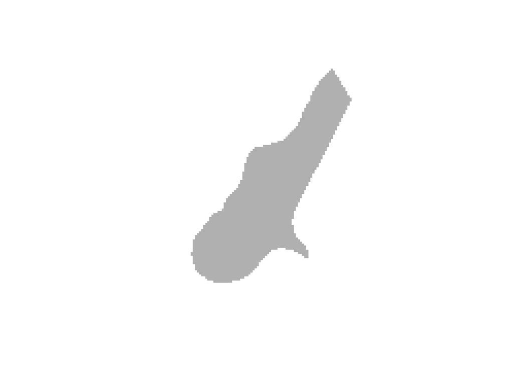

```r
data(meuse.grid)
coordinates(meuse.grid) <- c("x", "y")
meuse.grid <- as(meuse.grid, "SpatialPixels")
image(meuse.grid, col = "grey")
```

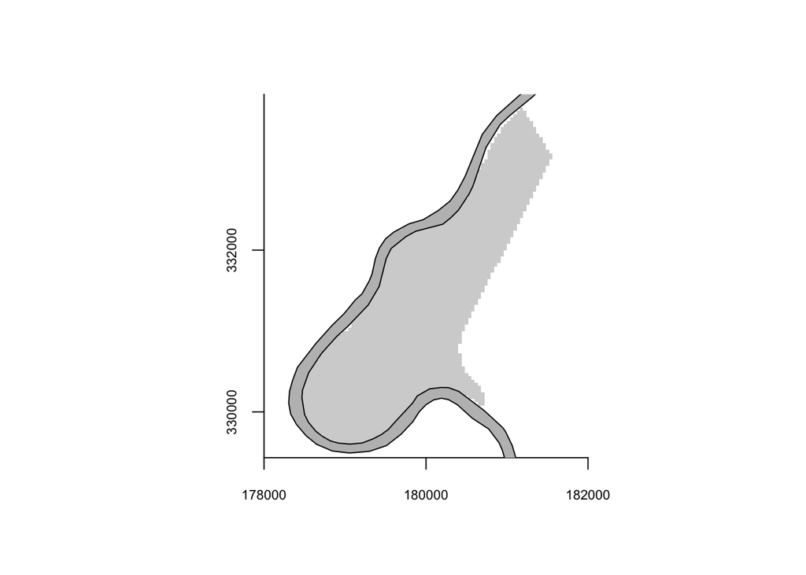

```r
image(meuse.grid, col = "lightgrey")
axis(1, at = c(178000 + 0:2 * 2000), cex.axis = 0.7)
axis(2, at = c(326000 + 0:4 * 2000), cex.axis = 0.7, pos=178000)
plot(meuse.sr, col = "grey", add = TRUE)
```

## Exercise: import National Park Boundaries

```r
nps <-  readOGR("/Users/nicoleangeli/Dropbox/R/Smithsonian_Rworkshop/NPS Boundary","nps_boundary")
```

```r
#str(nps)
#plot(nps) this file is huge. do not do this
#head(nps) this is better.

#head(nps, n=10)
#  GIS_LOC_ID UNIT_CODE GROUP_CODE                  UNIT_NAME                     UNIT_TYPE META_MIDF LANDS_CODE  DATE_EDIT
#0       <NA>      UPDE       <NA>             Upper Delaware Scenic and Recreational River      <NA>       <NA> 2006/06/06
#1       <NA>      BAND       <NA>                  Bandelier             National Monument      <NA>       <NA>       <NA>
#2       <NA>      ABLI       <NA> Abraham Lincoln Birthplace        National Historic Site      <NA>       <NA>       <NA>
#3       <NA>      ACAD       <NA>                     Acadia                 National Park      <NA>       <NA>       <NA>
#4       <NA>      ROCR       <NA>            Achbold Parkway                          Park      <NA>       <NA>       <NA>
#5       <NA>      ADAM       <NA>                      Adams      National Historical Park      <NA>       <NA>       <NA>
#6       <NA>      AGFO       <NA>          Agate Fossil Beds             National Monument      <NA>       <NA>       <NA>
#7       <NA>      ALFL       <NA>    Alibates Flint Quarries             National Monument      <NA>       <NA>       <NA>
#8       <NA>      ALPO       <NA> Allegheny Portage Railroad        National Historic Site      <NA>       <NA>       <NA>
#9       <NA>      AMME       <NA>     American Memorial Park                          <NA>      <NA>       <NA>       <NA>
```

Look at UNIT_NAME: you’ll notice that you can use just the unique park name

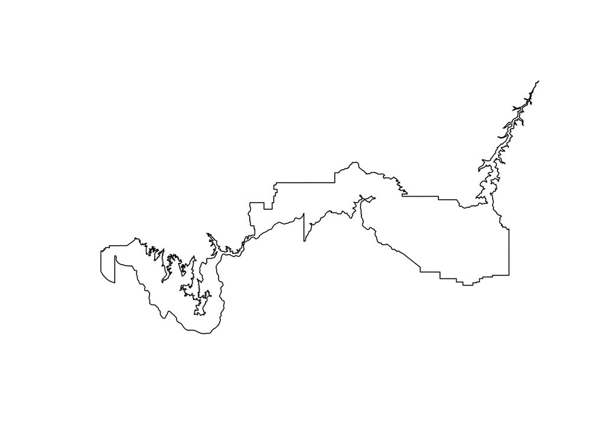

```r
grand.canyon <- nps[nps@data$UNIT_NAME == "Grand Canyon",] ##try it yourself!
plot(grand.canyon)
```

## Example in data manipulation: Buck Island Reef

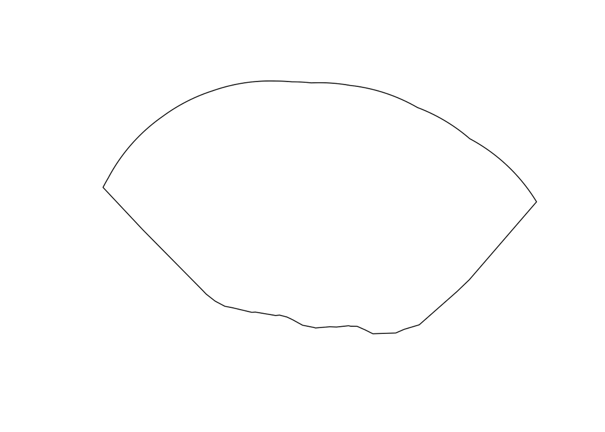

```r
###############
buck.map <- nps[nps@data$UNIT_NAME == "Buck Island Reef",]
plot(buck.map)
```

This worked, but it is the marine park, which includes both water AND land! I only work on the land. If I find a coastline shapefile, I can crop:

```r
coast<-  readOGR("/Users/nicoleangeli/Dropbox/PhD/Dissertation Data/GIS/GAP/USVIGapDVD/GISdata/Ancillary/USVI_Coastline","USVI_Coastline")
```

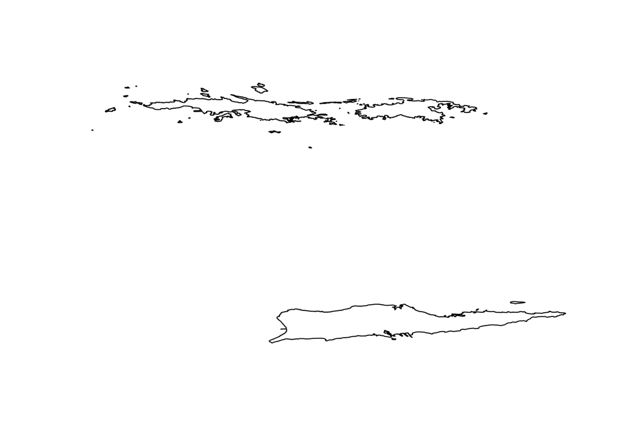

```r
#str(coast)
plot(coast)
```

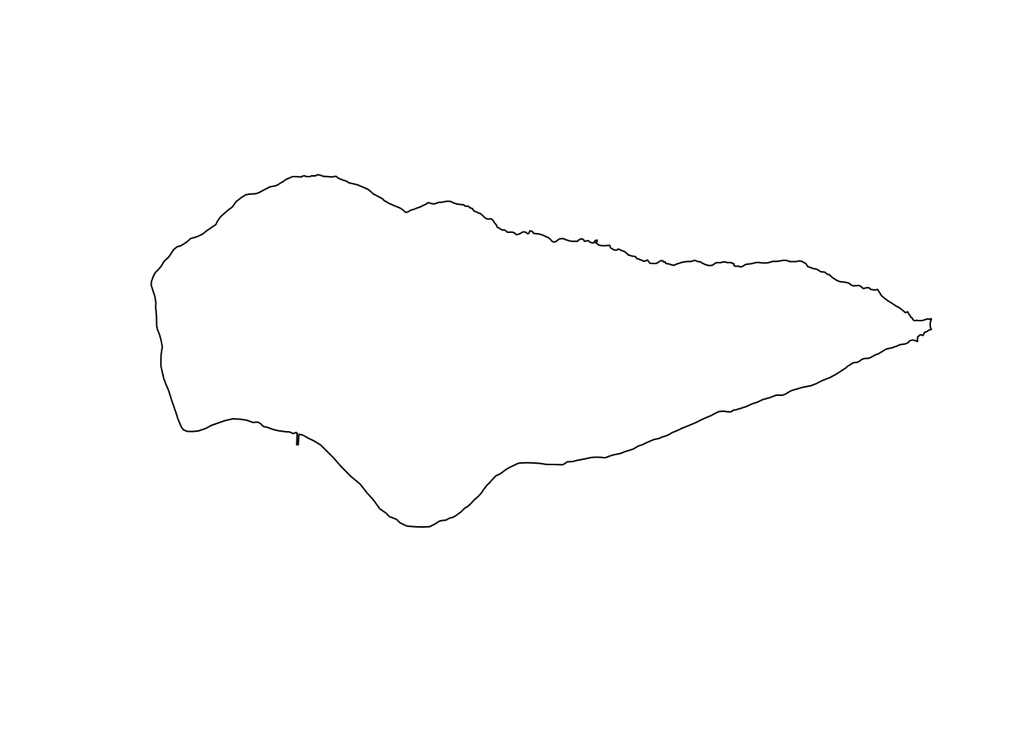

```r
#Extract from another big shapefile: Buck Island
buck.land <- coast[coast@data$FEA_NAME == "Buck Island (STC)",] ##This works. buck land
plot(buck.land)
```

Make them both the same datum (anchors coordinates) and ellipse (shape of the earth). This is important! For example, NAD83(1986) was equivalent to WGS84 when it was created. However, in 1994 WGS84 was aligned to a different reference frame. This correction resulted in coordinate differences of up to 1-1.5m with respect to NAD83.

### Converting between maps (datum/ellipse/coordinate systems)

Furthermore, you may have a choice in using UTM or coordinates. I’d recommend UTM, as it splits the earth into 60 zones (based on WGS84 ellipsoid and Mercator projection) - in R, you’ll need the zone and ellipsoid model:for e.g. #proj4string(x) <-CRS(“+proj=utm +zone=10 +datum=WGS84”)

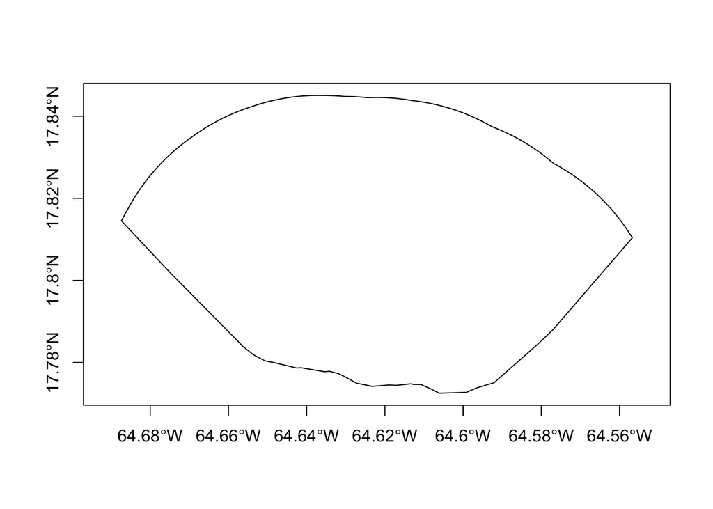

```r
#LatLong
buckMarine.WGS84.map <- spTransform(buck.map, CRS("+proj=longlat +datum=WGS84 +no_defs +ellps=WGS84 +towgs84=0,0,0"))
plot(buckMarine.WGS84.map, axes=TRUE)
```

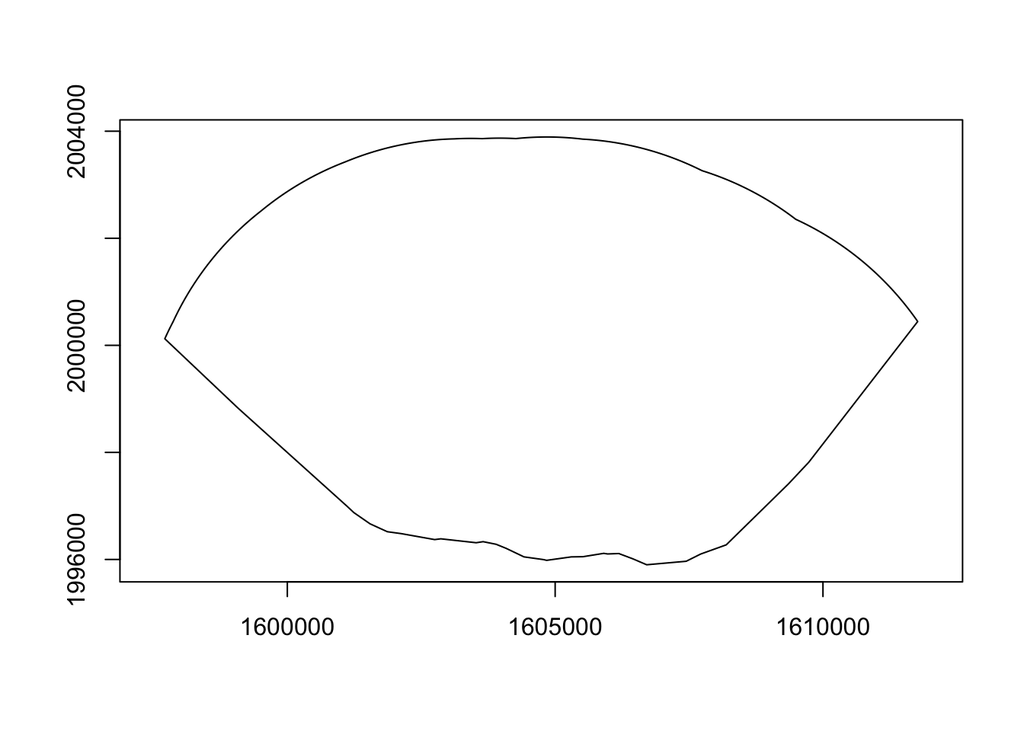

```r
#UTM
buck.WGS84.UTM <- spTransform(buck.map, CRS("+proj=utm +zone=18 +datum=WGS84 +ellps=WGS84 +towgs84=0,0,0"))
plot(buck.WGS84.UTM, axes=TRUE)
```

```r
#latlong
buck.WGS84.map <- spTransform(buck.land, CRS("+proj=longlat +datum=WGS84 +no_defs +ellps=WGS84 +towgs84=0,0,0"))
```

## Rasterize (see ppt slides)

Prepare a space to place your polygon as a raster.

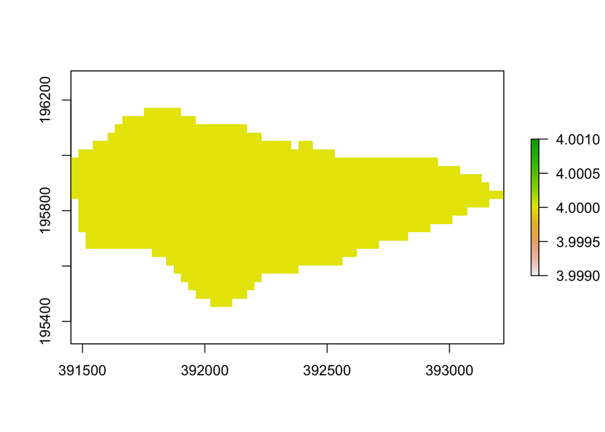

```r
buck.landR<-raster(extent(buck.land)) #makes spaces
projection(buck.landR)<-proj4string(buck.land) #makes a projection
#cord. ref = "+proj=longlat +ellps=GRS80 +towgs84=0,0,0,0,0,0,0 +no_defs"
res(buck.landR)<-30.0 #extent 30 m

buckLandRaster<-rasterize(buck.land, field= "FEA_NAME", buck.landR) #Abracadaba!
plot(buckLandRaster)
```

From there, you can assign values onto each raster cell, for example if you had a model of specific abundance, a density probability function, a distribution raster from a BEAST object, etc. #water_scaledSite<-extract(scale1_s, buckLandRaster) #setValues(Raster, CellValues) If you had converted this polygon into a raster, and you wanted to know the value at a certain locality: #extract(raster, c(coordinates))

# FUNCTIONS

## What is a function?

A way to separate your code into blocks, with inputs and outputs Lots of functions built into R or included in packages examples - mean, sd, str, attach, reshape, tapply

## Why a function?

> - running the same code over and over within your own code
> - parsing your code into groups for readability/usability
> - letting others use your code

## syntax for functions

```r
function_name <- function (variable) { code }
function_name(variable)
```

## First, simulate some realistic looking data

```r
#Written by Liam Revell: http://blog.phytools.org/2014/07/new-user-controls-in-phylotomap.html
foo<-function() paste(c(sample(LETTERS,1),
  sample(letters,round(runif(n=1,min=3,max=5))),"_",
  sample(letters,round(runif(n=1,min=4,max=6)))),collapse="")
tree<-pbtree(n=40,tip.label=replicate(40,foo()))
tree$edge.length<-tree$edge.length*100/max(nodeHeights(tree))
lat<-fastBM(tree,sig2=10,bounds=c(-90,90))
long<-fastBM(tree,sig2=20,bounds=c(-180,180))
X<-cbind(lat,long)
```

## Now, let do the same thing with the function.

```r
# function depends on phytools (& dependencies) and maps (& dependencies)
# written by Liam J. Revell 2013
library(maps)
phylo.to.mapDec8<-function(tree,coords,rotate=TRUE,...){
    # optional arguments
    if(hasArg(database)) database<-list(...)$database
    else database<-"world"
    if(hasArg(regions)) regions<-list(...)$regions
    else regions<-"."
    if(hasArg(plot)) plot<-list(...)$plot
    else plot<-TRUE
    if(hasArg(xlim)) xlim<-list(...)$xlim
    else xlim<-c(-180,180)
    if(hasArg(ylim)) ylim<-list(...)$ylim
    else ylim<-c(-90,90)
    # create a map
    map<-map(database,regions,xlim=xlim,ylim=ylim,plot=FALSE,fill=TRUE,resolution=0)
    # if rotate
    if(hasArg(type)) type<-list(...)$type else type<-"phylogram"
    if(rotate&&type=="phylogram") tree<-minRotate(tree,coords[,2])
    x<-list(tree=tree,map=map,coords=coords)
    class(x)<-"phylo.to.map"
    if(plot) plot.phylo.to.map(x,...)
    invisible(x)
}

# function to plot object of class "phylo.to.map"
# written by Liam J. Revell 2013, 2014

plot.phylo.to.map<-function(x,type=c("phylogram","direct"),...){
    type<-type[1]
    if(class(x)=="phylo.to.map"){
        tree<-x$tree
        map<-x$map
        coords<-x$coords
    } else stop("x should be an object of class \"phylo.to.map\"")
    # get optional arguments
    if(hasArg(xlim)) xlim<-list(...)$xlim
    else xlim<-map$range[1:2]
    if(hasArg(ylim)) ylim<-list(...)$ylim
    else ylim<-map$range[3:4]
    if(hasArg(fsize)) fsize<-list(...)$fsize
    else fsize<-1.0
    if(hasArg(split)) split<-list(...)$split
    else split<-c(0.4,0.6)
    if(hasArg(psize)) psize<-list(...)$psize
    else psize<-1.0
    if(hasArg(mar)) mar<-list(...)$mar
    else mar<-rep(0,4)
    if(hasArg(asp)) asp<-list(...)$asp
    else asp<-1.0
    if(hasArg(ftype)) ftype<-list(...)$ftype
    else ftype<-"reg"
    ftype<-which(c("off","reg","b","i","bi")==ftype)-1
    if(!ftype) fsize=0
    if(hasArg(from.tip)) from.tip<-list(...)$from.tip
    else from.tip<-FALSE
    if(hasArg(colors)) colors<-list(...)$colors
    else colors<-"red"
    if(length(colors)!=2) rep(colors[1],2)->colors
    # recompute ylim to leave space for the tree
    if(type=="phylogram") ylim<-c(ylim[1],ylim[2]+split[1]/split[2]*(ylim[2]-ylim[1]))
    # open & size a new plot
    par(mar=mar)
    plot.new()
    plot.window(xlim=xlim,ylim=ylim,asp=asp)
    map(map,add=TRUE,fill=TRUE,col="gray95",mar=rep(0,4))
    if(type=="phylogram"){
        # plot a white rectangle
        dx<-abs(diff(xlim))
        rect(xlim[1]-1.04*dx,ylim[2]-split[1]*(ylim[2]-ylim[1]),xlim[2]+1.04*dx,ylim[2],col="white",border="white")
        # rescale tree so it fits in the upper half of the plot
        # with enough space for labels
        sh<-(fsize*strwidth(tree$tip.label))/(par()$usr[2]-par()$usr[1])*(par()$usr[4]-par()$usr[3])
        tree$edge.length<-tree$edge.length/max(nodeHeights(tree))*(split[1]*(ylim[2]-ylim[1])-max(sh))
        n<-length(tree$tip.label)
        # reorder cladewise to assign tip positions
        cw<-reorder(tree,"cladewise")
        x<-vector(length=n+cw$Nnode)
        x[cw$edge[cw$edge[,2]<=n,2]]<-0:(n-1)/(n-1)*(xlim[2]-xlim[1])+xlim[1]
        # reorder pruningwise for post-order traversal
        pw<-reorder(tree,"pruningwise")
        nn<-unique(pw$edge[,1])
        # compute horizontal position of each edge
        for(i in 1:length(nn)){
            xx<-x[pw$edge[which(pw$edge[,1]==nn[i]),2]]
            x[nn[i]]<-mean(range(xx))
        }
        # compute start & end points of each edge
        Y<-ylim[2]-nodeHeights(cw)
        # plot vertical edges
        for(i in 1:nrow(Y)) lines(rep(x[cw$edge[i,2]],2),Y[i,],lwd=2,lend=2)
        # plot horizontal relationships
        for(i in 1:tree$Nnode+n) lines(range(x[cw$edge[which(cw$edge[,1]==i),2]]),Y[which(cw$edge[,1]==i),1],lwd=2,lend=2)
        # plot coordinates & linking lines
        coords<-coords[tree$tip.label,2:1]
        points(coords,pch=16,cex=psize,col=colors[2])
        for(i in 1:n) lines(c(x[i],coords[i,1]),c(Y[which(cw$edge[,2]==i),2]-if(from.tip) 0 else sh[i],coords[i,2]),col=colors[1],lty="dashed")
        # plot tip labels
        for(i in 1:n) text(x[i],Y[which(cw$edge[,2]==i),2],sub("_"," ",tree$tip.label[i]),pos=4,offset=0.1,
            srt=-90,cex=fsize,font=ftype)
    } else if(type=="direct"){
        phylomorphospace(tree,coords[,2:1],add=TRUE,label="horizontal",node.size=c(0,psize),lwd=1,
            control=list(col.node=setNames(rep(colors[2],max(tree$edge)),1:max(tree$edge)),
            col.edge=setNames(rep(colors[1],nrow(tree$edge)),tree$edge[,2])))
    }
}

# rotates all nodes to try and match tip ordering to longitude
# written by Liam J. Revell 2013

minRotate<-function(tree,x){
    tree<-reorder(tree)
    nn<-1:tree$Nnode+length(tree$tip.label)
    x<-x[tree$tip.label]
    for(i in 1:tree$Nnode){
        tt<-read.tree(text=write.tree(rotate(tree,nn[i])))
        oo<-sum(abs(order(x[tree$tip.label])-1:length(tree$tip.label)))
        pp<-sum(abs(order(x[tt$tip.label])-1:length(tt$tip.label)))
        if(oo>pp) tree<-tt
        message(paste("objective:",min(oo,pp)))
    }
    return(tree)
}
```

```r
## ok, first the (new) standard plot:
objDec8<-phylo.to.mapDec8(tree,X,ftype="i",fsize=0.7, asp=1.2,split=c(0.5,0.5))
obj<-phylo.to.map(tree,X,ftype="i",fsize=0.7, asp=1.2,split=c(0.5,0.5))
```

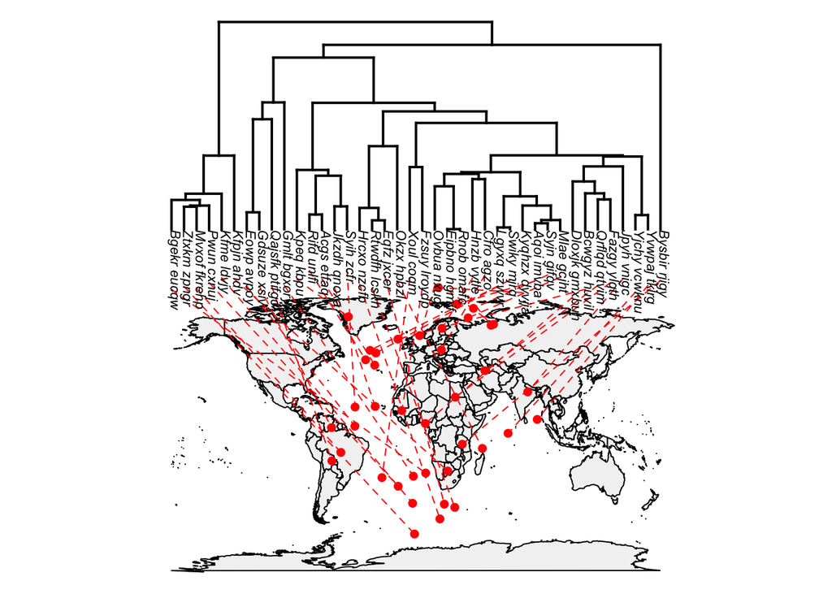

```r
## ok, first the (new) standard plot:
objDec8<-phylo.to.mapDec8(tree,X,ftype="i",fsize=0.7, asp=1.2,split=c(0.5,0.5))
```

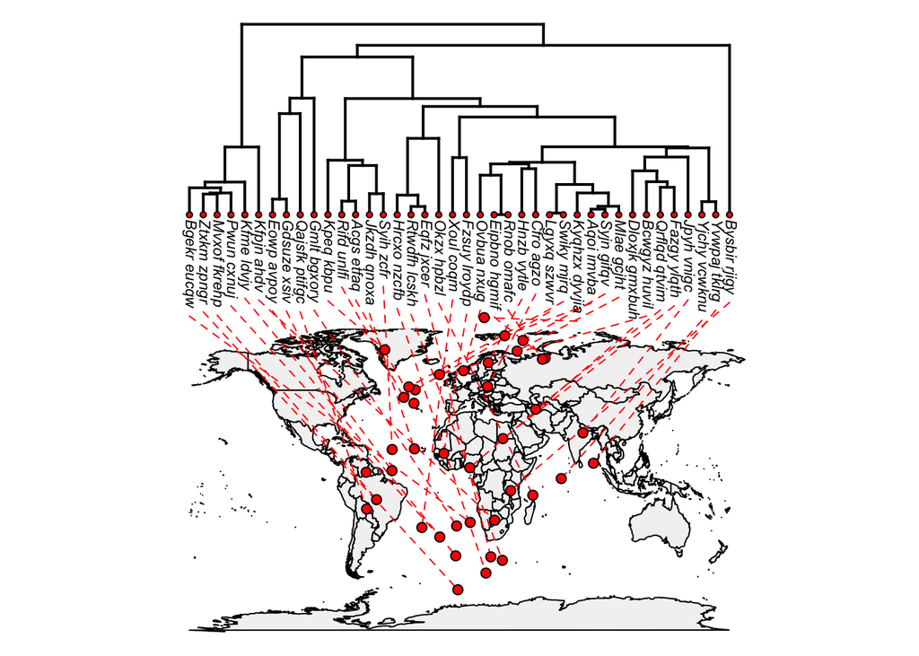

```r
obj<-phylo.to.map(tree,X,ftype="i",fsize=0.7, asp=1.2,split=c(0.5,0.5))
```

## Example: Merging data across a tree and geophylogeny!

### Format phylogenetic dataset

```r
#Load my data
setwd("/Users/nicoleangeli/Dropbox/PhD/Smithsonian/Morphological Data and Tissue")
coord<-read.csv("phylo_coords_tucker.csv") #coordinates of each specimen
TuckerTreeM<-read.tree("Pholidoscelis_boots.tre") #tree file
AmeivaTree<-TuckerTreeM #rename
PC<-read.csv("PCA_AM.csv") #data for each species
morph_Am<-read.csv("morphJul25.csv") #data for each species
traits<-cbind(morph_Am[,14:24], morph_Am[,26:29]) #selecting relevant data
species_AM<-cbind(as.factor(morph_Am[,5]), morph_Am[,10],traits) #fix and format data types

#Rename my tree and data to correspond to my datasets
species<-c("P._wetmorei","P.exsul1","P._dorsalis","P._auberi2", "Holcosus_quadrilineatus","P._corax","")
names(species_AM)<-c("mongoose","species","Head.Width","Head.Length","SnoutEar","Toe","RHfemur","RHtibia","LHfemur","LHtibia","Chin","Aplates","Ashields","RFem","LFem","SVL","Tail")
```

```r
#Summarize and create datasheets
AmeivaTraits<-ddply(species_AM, .(species), summarize, Head.Width=mean(Head.Width), Head.Length=mean(Head.Length), SnoutEar=mean(SnoutEar), Toe=mean(Toe), RHfemur=mean(RHfemur), RHtibia=mean(RHtibia), LHfemur=mean(LHfemur), LHtibia=mean(LHtibia), Chin=mean(Chin), Aplates=mean(Aplates), Ashields=mean(Ashields), RFem=mean(RFem), LFem=mean(LFem), SVL=mean(SVL), Tail=mean(Tail))
mongoose<-c(1,1,0,1,1,0,1,1,0,0,1,0,1,1,0)
AmeivaTraits_only<-rbind(AmeivaTraits[1:2,],AmeivaTraits[6:18,])

#Merge a datasheets
AmeivaTraits_pc<-cbind(AmeivaTraits_only, PC,mongoose)
AmeivaTraits_pc<-as.data.frame(AmeivaTraits_pc)

#Create consistent naming
names(AmeivaTraits_pc)<-c("species","Head.Width","Head.Length","SnoutEar","Toe","RHfemur","RHtibia","LHfemur","LHtibia","Chin","Aplates","Ashields","RFem","LFem","SVL","Tail","speciesdup","PC1","PC2","PC3","PC4")
taxa2<-c("ameiv","P._auberi2","P._corax","P._dorsalis","edrac","P._erythrocephala","P._exsul2","fest","P._fuscata","P._griswoldi","P._lineolata","P._pluvianotata","polop","undul","P._wetmorei")
taxa3<-as.data.frame(taxa2)
taxa3[,1]
rownames(AmeivaTraits_pc)<-taxa3[,1]

#Check that all species are in the tree available to me
library(geiger)
AmeivaNodata<-name.check(AmeivaTree, AmeivaTraits_pc)
NewAmeivaTree<-drop.tip(AmeivaTree, AmeivaNodata$tree_not_data,trim.internal=TRUE) ###TREE
ultrametricNewAmeivaTree0<-chronopl(NewAmeivaTree, lambda=0)
plot(ultrametricNewAmeivaTree0)
rownames(coord)<-coord[,3]

#Use the tree with the data and the coordinates of each species for the mapping
plotMap<-phylo.to.map(ultrametricNewAmeivaTree0, coord[,1:2], rotate=TRUE, xlim=c(-85,-55), ylim=c(7,25))
```

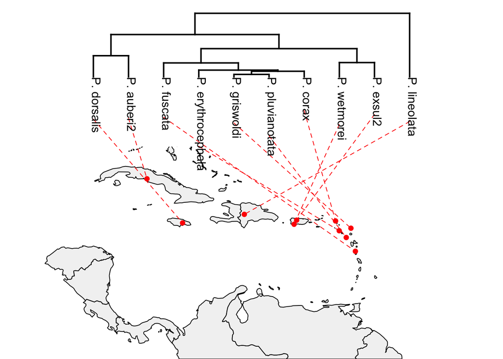

```r
plot(plotMap)
```

### basic code: http://cran.r-project.org/web/packages/sp/vignettes/sp.pdf

### detailed code: http://cran.r-project.org/web/packages/sp/sp.pdf

### detailed info: Applied Spatial Data Analysis with R - Bivand, et al.